# Final Project

Harsimran Ghai

2026-04-17

My github link is https://github.com/harsimranghai91-eng/Final-Project-CHEP-898.git.

# Introduction to the project

Myocardial infarction occurs due to decrease in blood supply to the myocardium (Heart Muscles), commonly due to obstruction in the coronary arteries. The risk factors for MI are as follows: Smoking, alcohol intake, sociodemographic factors, diet, increase level of homocysteine, diabetes, hypertension, high cholesterol, sedentary lifestyle, obesity (1). The global prevalence of MI is 3.8% for people age less than 60 and 9.5% for people greater than 60 years of age (2). Given, its global burden, it is imperative to create a predictive model that can predict the person risk of having the heart attack based on certain features.

# Objectives of this study

The main objective of this study is to create different predictive models for predicting myocardial infarction (Heart attack). The best machine learning model will be selected based on different criterias (Refer to model selection in methodology section)

# Methodology

## Statistical methods

### machine Learning models

Four different classification machine learning models was created that is logistic regression, logistic regression with up-sampling, random forest and random forest with up- sampling. The reason behind using random forest rather than decision tree is that decision tree even though easy to interpret tend to underperform in comparison to logistics regression models, that why ensemble method (random forest) is used. Additionally, the reason behind using up-sampling is the vast proportion difference of people with heart attack and without heart attack in this dataset.The up-sampling tend to balance such difference.

The recipe was created such that variables that are irrelevant such as patientID, province, and hypertension status were removed. The hypertension was removed as we have continuous blood pressure measurements which improves the power of the model in comparison to using only hypertension categorical variable. Listwise deletion was perform to remove observations with missing variables information. Additionally,the dummy coding of the categorical variables that have more than two levels was done. Further, predictors with non zero variance and numeric predictor that are highly related were deleted (if any).

### Model comparison

The performance of each model was compared using the following criteria : Accuracy, sensitivity, specificity, precision, and F1 Score. The model with the high score for the parameters will be selected as the best predictive model.

### Variable Information

#### Independent Variables

1. **Age** – Continuous
2. **Blood Pressure** – Continuous
3. **CVD Risk Score** – Continuous
4. **Hypertension** – Binary
5. **Diabetes** – Binary
6. **Obesity** – Binary
7. **Cholesterol** – Categorical (High, Normal, Low)
8. **Air Pollution Exposure** – Categorical (High, Medium, Low)
9. **Physical Activity** – Categorical (High, Medium, Low)
10. **Diet Score** – Categorical (Poor, Moderate, Healthy)
11. **Stress Level** – Categorical (Low, Medium, High)
12. **Alcohol Consumption** – Binary
13. **Family History CVD** – Binary
14. **Healthcare Access** – Categorical (Poor, Moderate, Good)
15. **Rural or Urban** – Binary
16. **Hospital Availability** – Categorical (Low, Medium, High)
17. **TCM Use** – Binary
18. **Employment Status** – Categorical (Employed, Unemployed, Retired)
19. **Education Level** – Categorical (None, Primary, Secondary, Higher)
20. **Income Level** – Categorical (Low, Middle, High)
21. **Chronic Kidney Disease** – Binary
22. **Previous Heart Attack** – Binary

# Data Wrangling

## Loading the Data

```r
data<-read.csv("heart_attack_china.csv")
```

## Loading the packages

```r
library(tidyverse)
library(tidymodels)
```

```r
library(reportRmd)
library(sjPlot)
library(plotly)
library(psych)
library(parallel)
library(finalfit)
library(gtsummary)
library(mlbench)
library(vip)
library(rsample)
library(tune)
library(recipes)
library(yardstick)
library(parsnip)
library(glmnet)
library(themis)
library(corrr)
library(performance)
library(utils)
library(see)
library(forestmodel)
```

## Taking a look into data set

```r
glimpse(data)
```

```
## Rows: 239,266
## Columns: 28
## $ Patient_ID             <int> 1, 2, 3, 4, 5, 6, 7, 8, 9, 10, 11, 12, 13, 14, …
## $ Age                    <int> 55, 66, 69, 45, 39, 76, 37, 88, 54, 47, 62, 83,…
## $ Gender                 <chr> "Male", "Female", "Female", "Female", "Female",…
## $ Smoking_Status         <chr> "Non-Smoker", "Smoker", "Smoker", "Smoker", "Sm…
## $ Hypertension           <chr> "No", "Yes", "No", "No", "No", "No", "No", "Yes…
## $ Diabetes               <chr> "No", "No", "No", "Yes", "No", "No", "No", "No"…
## $ Obesity                <chr> "Yes", "No", "No", "No", "No", "No", "No", "Yes…
## $ Cholesterol_Level      <chr> "Normal", "Low", "Low", "Normal", "Normal", "Lo…
## $ Air_Pollution_Exposure <chr> "High", "Medium", "Medium", "Medium", "Medium",…
## $ Physical_Activity      <chr> "High", "High", "High", "Low", "Medium", "Low",…
## $ Diet_Score             <chr> "Moderate", "Healthy", "Moderate", "Healthy", "…
## $ Stress_Level           <chr> "Low", "Medium", "Low", "Medium", "Low", "Mediu…
## $ Alcohol_Consumption    <chr> "Yes", "No", "No", "Yes", "No", "No", "No", "No…
## $ Family_History_CVD     <chr> "No", "Yes", "No", "No", "No", "Yes", "Yes", "N…
## $ Healthcare_Access      <chr> "Good", "Poor", "Poor", "Poor", "Moderate", "Mo…
## $ Rural_or_Urban         <chr> "Rural", "Urban", "Rural", "Rural", "Urban", "U…
## $ Region                 <chr> "Eastern", "Eastern", "Eastern", "Central", "We…
## $ Province               <chr> "Beijing", "Qinghai", "Henan", "Qinghai", "Guan…
## $ Hospital_Availability  <chr> "Low", "High", "Low", "Medium", "Low", "Low", "…
## $ TCM_Use                <chr> "Yes", "No", "No", "Yes", "No", "Yes", "Yes", "…
## $ Employment_Status      <chr> "Unemployed", "Unemployed", "Unemployed", "Empl…
## $ Education_Level        <chr> "Primary", "Secondary", "Primary", "Primary", "…
## $ Income_Level           <chr> "Low", "Middle", "High", "Low", "Middle", "Midd…
## $ Blood_Pressure         <int> 104, 142, 176, 178, 146, 92, 144, 162, 93, 125,…
## $ Chronic_Kidney_Disease <chr> "Yes", "No", "No", "No", "Yes", "No", "Yes", "N…
## $ Previous_Heart_Attack  <chr> "No", "No", "No", "Yes", "No", "No", "No", "No"…
## $ CVD_Risk_Score         <int> 78, 49, 31, 23, 79, 49, 81, 27, 62, 67, 94, 82,…
## $ Heart_Attack           <chr> "No", "No", "No", "No", "No", "No", "No", "No",…
```

## Checking duplicate observations

```r
sum(duplicated(data))
```

```
## [1] 0
```

No duplicated observation were observed in this dataset.

## Checking the missing data

```r
any(is.na(data))
```

```
## [1] FALSE
```

No missing data was found in this data set, so we don’t need to do anything for the missing data.

## Checking the structure of the data set

```r
str(data)
```

```
## 'data.frame':    239266 obs. of  28 variables:
##  $ Patient_ID            : int  1 2 3 4 5 6 7 8 9 10 ...
##  $ Age                   : int  55 66 69 45 39 76 37 88 54 47 ...
##  $ Gender                : chr  "Male" "Female" "Female" "Female" ...
##  $ Smoking_Status        : chr  "Non-Smoker" "Smoker" "Smoker" "Smoker" ...
##  $ Hypertension          : chr  "No" "Yes" "No" "No" ...
##  $ Diabetes              : chr  "No" "No" "No" "Yes" ...
##  $ Obesity               : chr  "Yes" "No" "No" "No" ...
##  $ Cholesterol_Level     : chr  "Normal" "Low" "Low" "Normal" ...
##  $ Air_Pollution_Exposure: chr  "High" "Medium" "Medium" "Medium" ...
##  $ Physical_Activity     : chr  "High" "High" "High" "Low" ...
##  $ Diet_Score            : chr  "Moderate" "Healthy" "Moderate" "Healthy" ...
##  $ Stress_Level          : chr  "Low" "Medium" "Low" "Medium" ...
##  $ Alcohol_Consumption   : chr  "Yes" "No" "No" "Yes" ...
##  $ Family_History_CVD    : chr  "No" "Yes" "No" "No" ...
##  $ Healthcare_Access     : chr  "Good" "Poor" "Poor" "Poor" ...
##  $ Rural_or_Urban        : chr  "Rural" "Urban" "Rural" "Rural" ...
##  $ Region                : chr  "Eastern" "Eastern" "Eastern" "Central" ...
##  $ Province              : chr  "Beijing" "Qinghai" "Henan" "Qinghai" ...
##  $ Hospital_Availability : chr  "Low" "High" "Low" "Medium" ...
##  $ TCM_Use               : chr  "Yes" "No" "No" "Yes" ...
##  $ Employment_Status     : chr  "Unemployed" "Unemployed" "Unemployed" "Employed" ...
##  $ Education_Level       : chr  "Primary" "Secondary" "Primary" "Primary" ...
##  $ Income_Level          : chr  "Low" "Middle" "High" "Low" ...
##  $ Blood_Pressure        : int  104 142 176 178 146 92 144 162 93 125 ...
##  $ Chronic_Kidney_Disease: chr  "Yes" "No" "No" "No" ...
##  $ Previous_Heart_Attack : chr  "No" "No" "No" "Yes" ...
##  $ CVD_Risk_Score        : int  78 49 31 23 79 49 81 27 62 67 ...
##  $ Heart_Attack          : chr  "No" "No" "No" "No" ...
```

## Changing the Structure of variables

```r
data <- data%>%mutate(across(c( Gender,
                                Smoking_Status,
                                Hypertension,
                                Diabetes,
                                Obesity,
                                Cholesterol_Level,
                                Air_Pollution_Exposure,
                                Physical_Activity,
                                Diet_Score,
                                Stress_Level,
                                Alcohol_Consumption,
                                Family_History_CVD,
                                Healthcare_Access,
                                Rural_or_Urban,
                                Hospital_Availability,
                                TCM_Use,
                                Employment_Status,
                                Education_Level,
                                Income_Level,
                                Chronic_Kidney_Disease,
                                Previous_Heart_Attack,
                                Heart_Attack

),~ as.factor(.)))
```

## Descriptive Analysis

```r
rm_covsum(
  data = data,
                        covs = c('Age',
                                'Blood_Pressure',
                                'CVD_Risk_Score',
                                'Hypertension',
                                'Diabetes',
                                'Obesity',
                                'Cholesterol_Level',
                                'Air_Pollution_Exposure',
                                'Physical_Activity',
                                'Diet_Score',
                                'Stress_Level',
                                'Alcohol_Consumption',
                                'Family_History_CVD',
                                'Healthcare_Access',
                                'Rural_or_Urban',
                                'Hospital_Availability',
                                'TCM_Use',
                                'Employment_Status',
                                'Education_Level',
                                'Income_Level',
                                'Chronic_Kidney_Disease',
                                'Previous_Heart_Attack',
                                'Heart_Attack')
)
```

|  | n=239266 |
| --- | --- |
| Age |  |
| Mean (sd) | 59.5 (17.3) |
| Median (Min,Max) | 59 (30, 89) |
| Blood Pressure |  |
| Mean (sd) | 134.5 (26.0) |
| Median (Min,Max) | 135 (90, 179) |
| CVD Risk Score |  |
| Mean (sd) | 54.5 (26.0) |
| Median (Min,Max) | 54 (10, 99) |
| Hypertension |  |
| No | 174557 (73) |
| Yes | 64709 (27) |
| Diabetes |  |
| No | 212794 (89) |
| Yes | 26472 (11) |
| Obesity |  |
| No | 167521 (70) |
| Yes | 71745 (30) |
| Cholesterol Level |  |
| High | 79620 (33) |
| Low | 79555 (33) |
| Normal | 80091 (33) |
| Air Pollution Exposure |  |
| High | 48019 (20) |
| Low | 71654 (30) |
| Medium | 119593 (50) |
| Physical Activity |  |
| High | 79250 (33) |
| Low | 80086 (33) |
| Medium | 79930 (33) |
| Diet Score |  |
| Healthy | 79656 (33) |
| Moderate | 79954 (33) |
| Poor | 79656 (33) |
| Stress Level |  |
| High | 79857 (33) |
| Low | 80120 (33) |
| Medium | 79289 (33) |
| Alcohol Consumption |  |
| No | 167156 (70) |
| Yes | 72110 (30) |
| Family History CVD |  |
| No | 179740 (75) |
| Yes | 59526 (25) |
| Healthcare Access |  |
| Good | 79643 (33) |
| Moderate | 79711 (33) |
| Poor | 79912 (33) |
| Rural or Urban |  |
| Rural | 143507 (60) |
| Urban | 95759 (40) |
| Hospital Availability |  |
| High | 79848 (33) |
| Low | 79589 (33) |
| Medium | 79829 (33) |
| TCM Use |  |
| No | 143949 (60) |
| Yes | 95317 (40) |
| Employment Status |  |
| Employed | 79638 (33) |
| Retired | 79872 (33) |
| Unemployed | 79756 (33) |
| Education Level |  |
| Higher | 59942 (25) |
| None | 59617 (25) |
| Primary | 59901 (25) |
| Secondary | 59806 (25) |
| Income Level |  |
| High | 80149 (33) |
| Low | 79797 (33) |
| Middle | 79320 (33) |
| Chronic Kidney Disease |  |
| No | 203597 (85) |
| Yes | 35669 (15) |
| Previous Heart Attack |  |
| No | 215306 (90) |
| Yes | 23960 (10) |
| Heart Attack |  |
| No | 210195 (88) |
| Yes | 29071 (12) |

## Bar Graphs

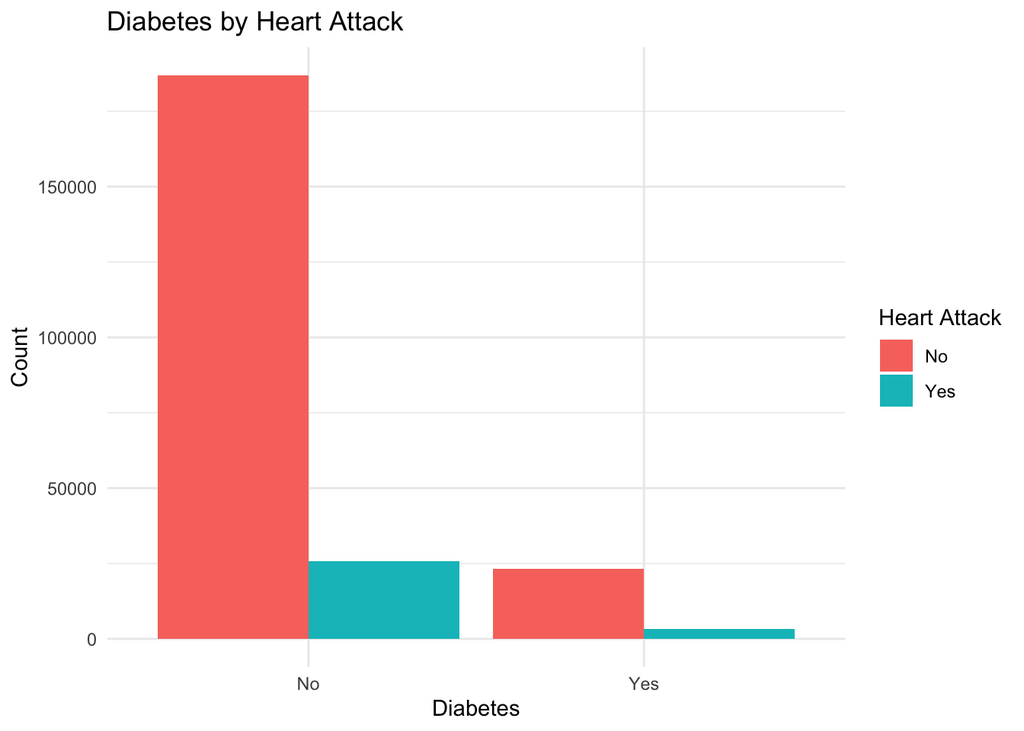

```r
ggplot(data, aes(x = Diabetes, fill = Heart_Attack)) +
  geom_bar(position = "dodge") +
  labs(
    title = "Diabetes by Heart Attack",
    x = "Diabetes",
    y = "Count",
    fill = "Heart Attack"
  ) +
  theme_minimal()
```

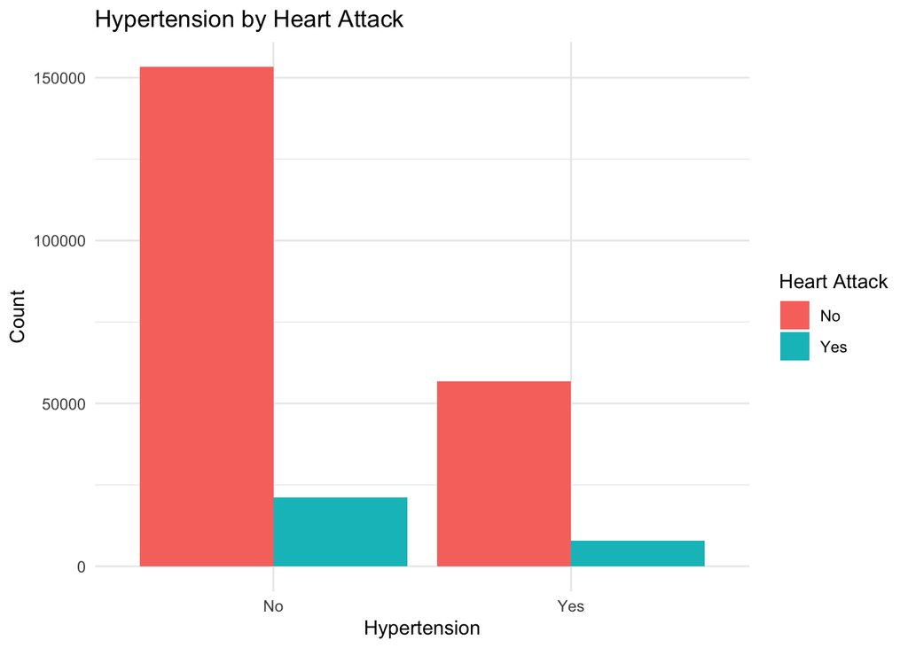

```r
ggplot(data, aes(x =Hypertension , fill = Heart_Attack)) +
  geom_bar(position = "dodge") +
  labs(
    title = "Hypertension by Heart Attack",
    x = "Hypertension",
    y = "Count",
    fill = "Heart Attack"
  ) +
  theme_minimal()
```

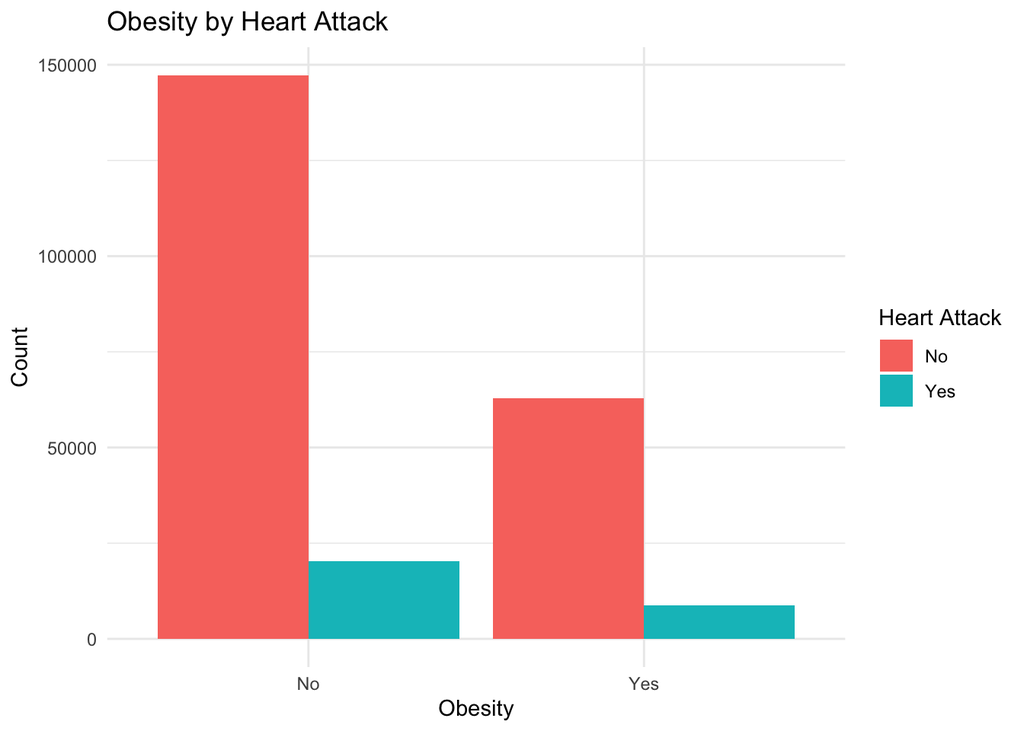

```r
ggplot(data, aes(x =Obesity , fill = Heart_Attack)) +
  geom_bar(position = "dodge") +
  labs(
    title = "Obesity by Heart Attack",
    x = "Obesity",
    y = "Count",
    fill = "Heart Attack"
  ) +
  theme_minimal()
```

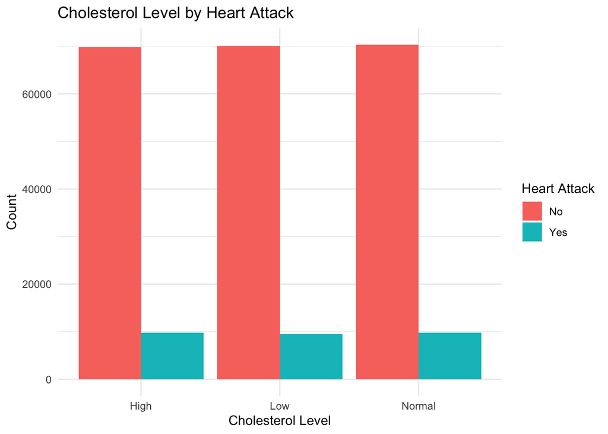

```r
ggplot(data, aes(x =Cholesterol_Level , fill = Heart_Attack)) +
  geom_bar(position = "dodge") +
  labs(
    title = "Cholesterol Level by Heart Attack ",
    x = "Cholesterol Level",
    y = "Count",
    fill = "Heart Attack"
  ) +
  theme_minimal()
```

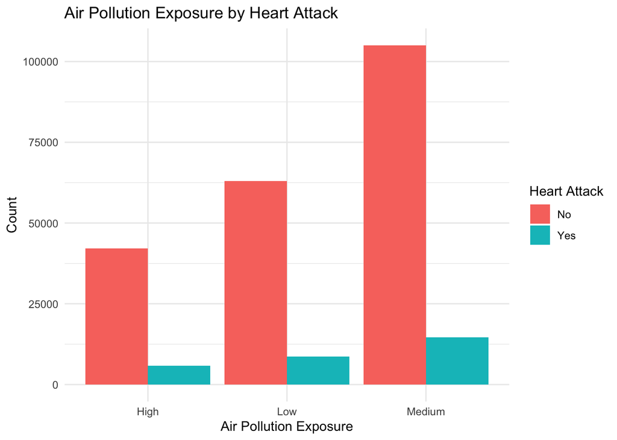

```r
ggplot(data, aes(x = Air_Pollution_Exposure, fill = Heart_Attack)) +
  geom_bar(position = "dodge") +
  labs(
    title = "Air Pollution Exposure by Heart Attack",
    x = "Air Pollution Exposure",
    y = "Count",
    fill = "Heart Attack"
  ) +
  theme_minimal()
```

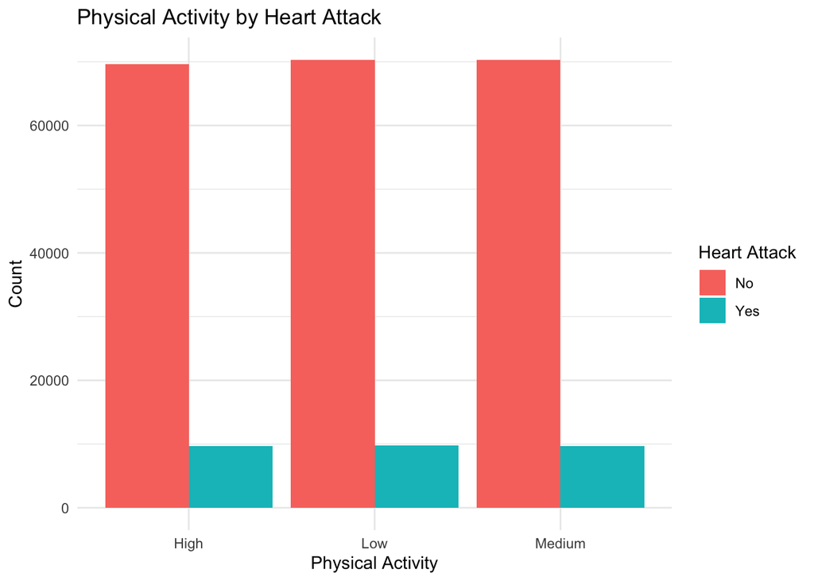

```r
ggplot(data, aes(x = Physical_Activity, fill = Heart_Attack)) +
  geom_bar(position = "dodge") +
  labs(
    title = "Physical Activity by Heart Attack",
    x = "Physical Activity",
    y = "Count",
    fill = "Heart Attack"
  ) +
  theme_minimal()
```

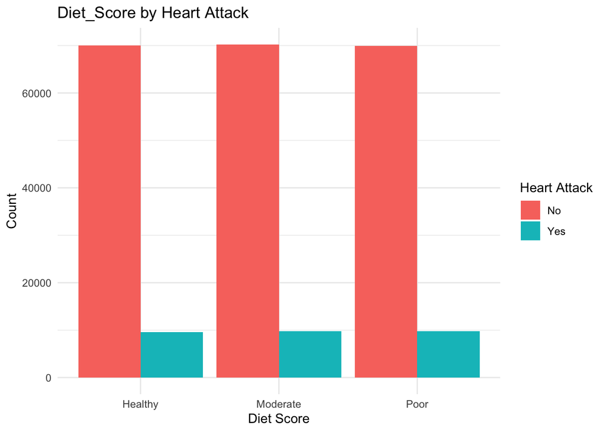

```r
ggplot(data, aes(x = Diet_Score, fill = Heart_Attack)) +
  geom_bar(position = "dodge") +
  labs(
    title = "Diet_Score by Heart Attack",
    x = "Diet Score",
    y = "Count",
    fill = "Heart Attack"
  ) +
  theme_minimal()
```

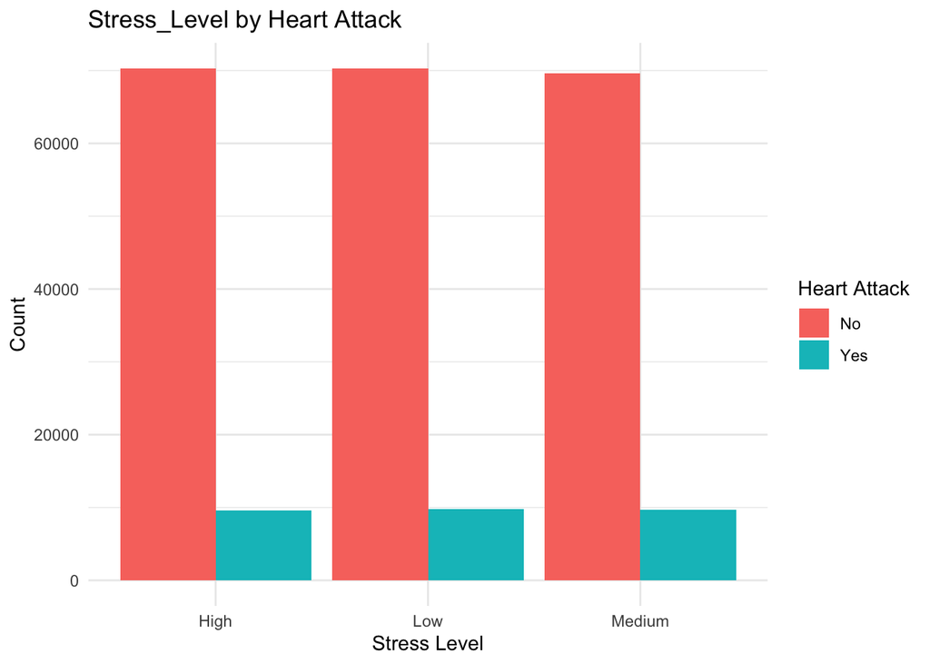

```r
ggplot(data, aes(x = Stress_Level, fill = Heart_Attack)) +
  geom_bar(position = "dodge") +
  labs(
    title = "Stress_Level by Heart Attack",
    x = "Stress Level",
    y = "Count",
    fill = "Heart Attack"
  ) +
  theme_minimal()
```

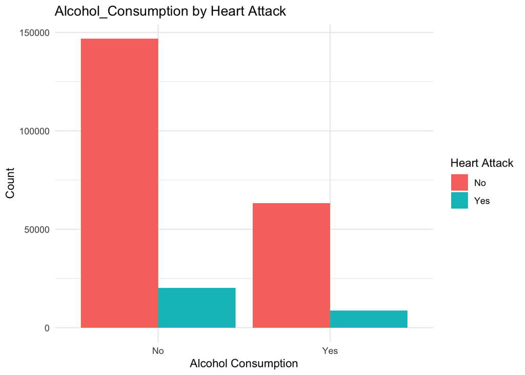

```r
ggplot(data, aes(x = Alcohol_Consumption, fill = Heart_Attack)) +
  geom_bar(position = "dodge") +
  labs(
    title = "Alcohol_Consumption by Heart Attack",
    x = "Alcohol Consumption",
    y = "Count",
    fill = "Heart Attack"
  ) +
  theme_minimal()
```

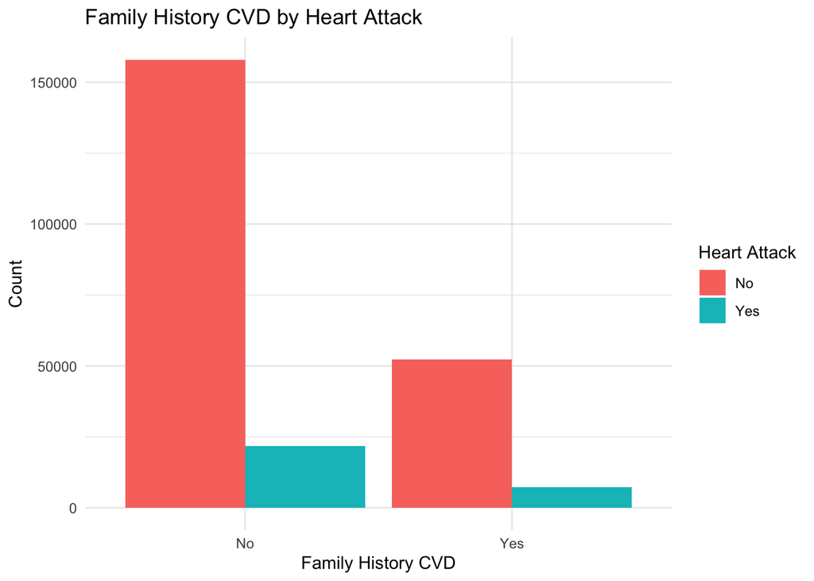

```r
ggplot(data, aes(x = Family_History_CVD, fill = Heart_Attack)) +
  geom_bar(position = "dodge") +
  labs(
    title = "Family History CVD by Heart Attack",
    x = "Family History CVD",
    y = "Count",
    fill = "Heart Attack"
  ) +
  theme_minimal()
```

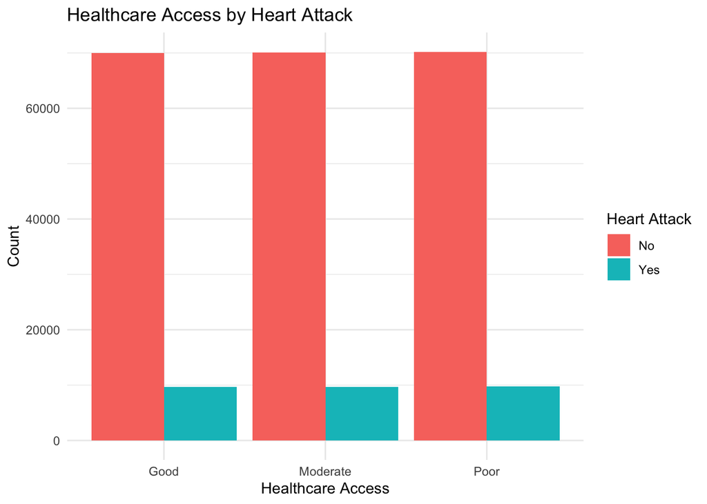

```r
ggplot(data, aes(x = Healthcare_Access, fill = Heart_Attack)) +
  geom_bar(position = "dodge") +
  labs(
    title = "Healthcare Access by Heart Attack",
    x = "Healthcare Access",
    y = "Count",
    fill = "Heart Attack"
  ) +
  theme_minimal()
```

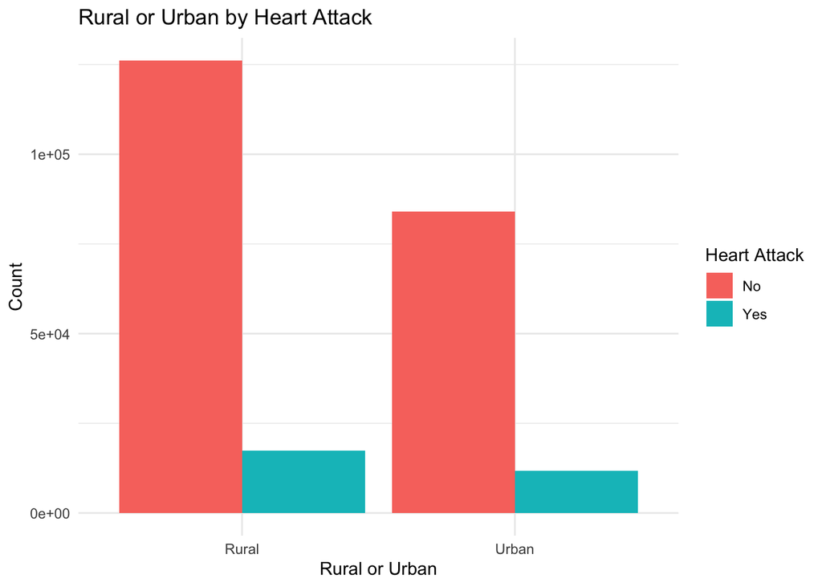

```r
ggplot(data, aes(x = Rural_or_Urban, fill = Heart_Attack)) +
  geom_bar(position = "dodge") +
  labs(
    title = "Rural or Urban by Heart Attack",
    x = "Rural or Urban",
    y = "Count",
    fill = "Heart Attack"
  ) +
  theme_minimal()
```

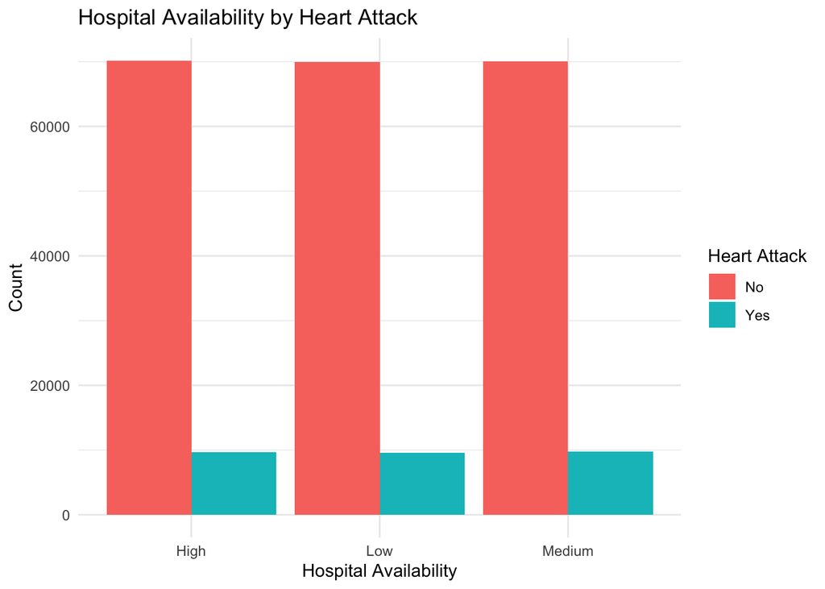

```r
ggplot(data, aes(x = Hospital_Availability, fill = Heart_Attack)) +
  geom_bar(position = "dodge") +
  labs(
    title = "Hospital Availability by Heart Attack",
    x = "Hospital Availability",
    y = "Count",
    fill = "Heart Attack"
  ) +
  theme_minimal()
```

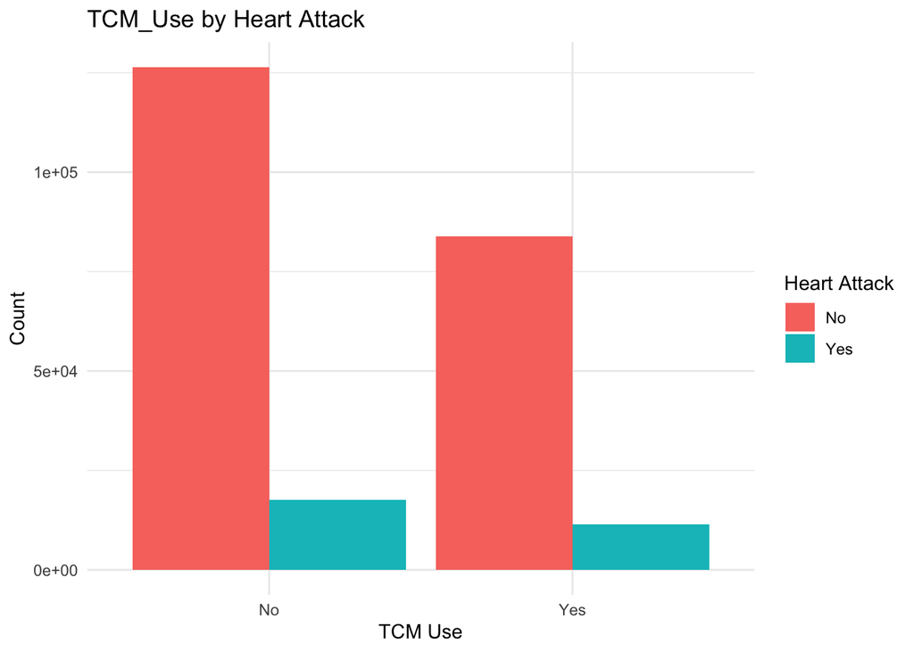

```r
ggplot(data, aes(x = TCM_Use, fill = Heart_Attack)) +
  geom_bar(position = "dodge") +
  labs(
    title = "TCM_Use by Heart Attack",
    x = "TCM Use",
    y = "Count",
    fill = "Heart Attack"
  ) +
  theme_minimal()
```

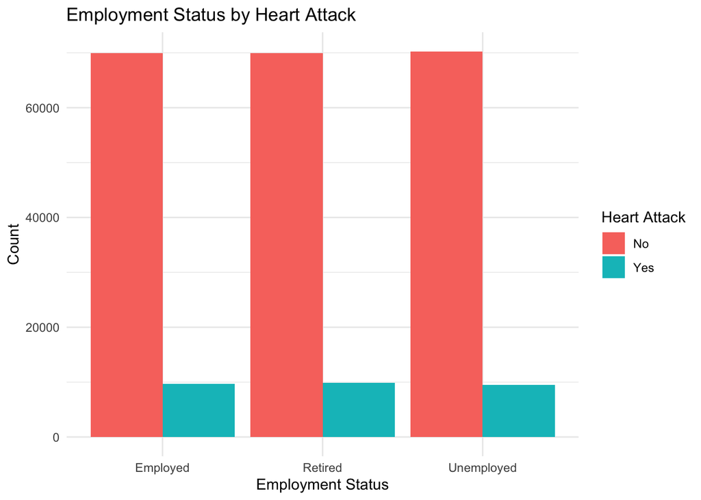

```r
ggplot(data, aes(x = Employment_Status, fill = Heart_Attack)) +
  geom_bar(position = "dodge") +
  labs(
    title = "Employment Status by Heart Attack",
    x = "Employment Status",
    y = "Count",
    fill = "Heart Attack"
  ) +
  theme_minimal()
```

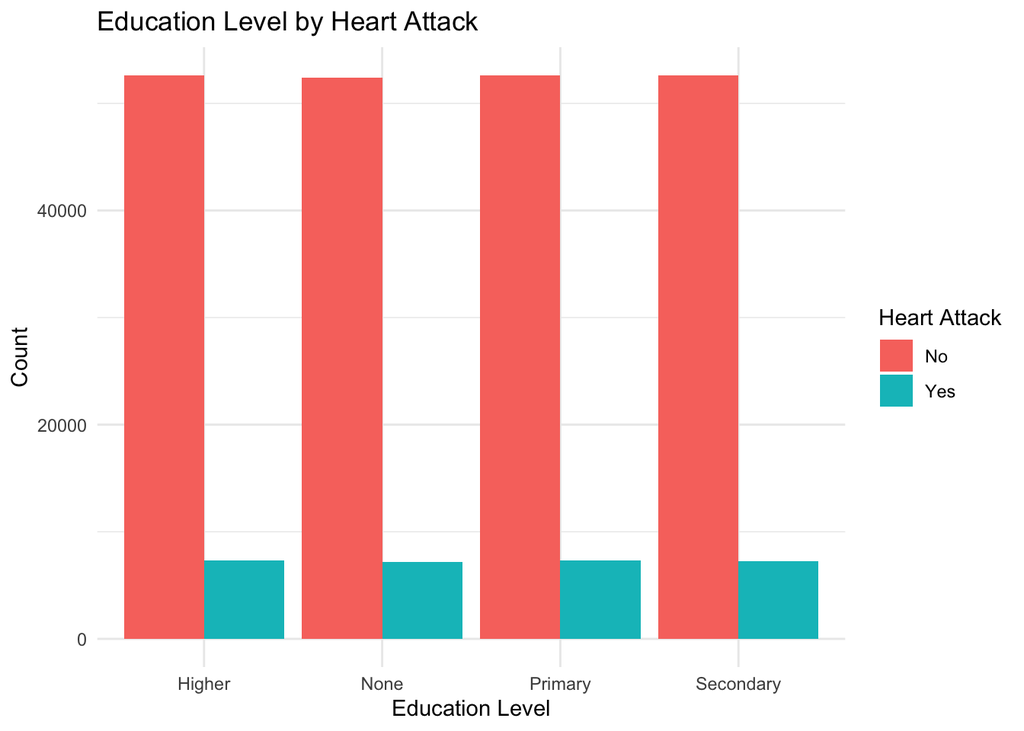

```r
ggplot(data, aes(x = Education_Level, fill = Heart_Attack)) +
  geom_bar(position = "dodge") +
  labs(
    title = "Education Level by Heart Attack",
    x = "Education Level",
    y = "Count",
    fill = "Heart Attack"
  ) +
  theme_minimal()
```

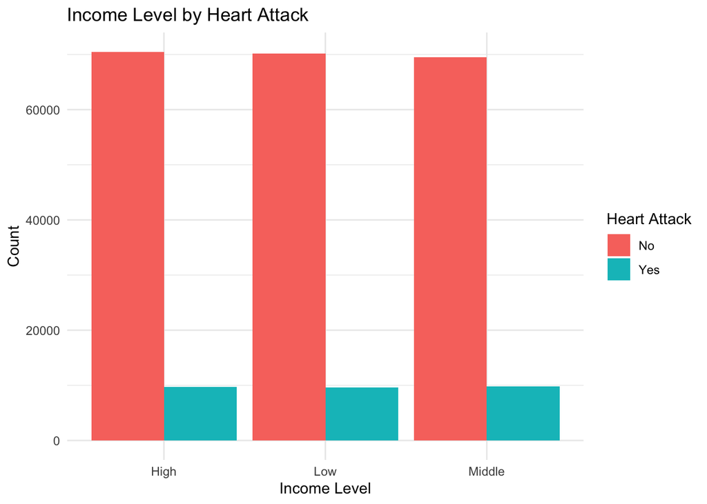

```r
ggplot(data, aes(x = Income_Level, fill = Heart_Attack)) +
  geom_bar(position = "dodge") +
  labs(
    title = "Income Level by Heart Attack",
    x = "Income Level",
    y = "Count",
    fill = "Heart Attack"
  ) +
  theme_minimal()
```

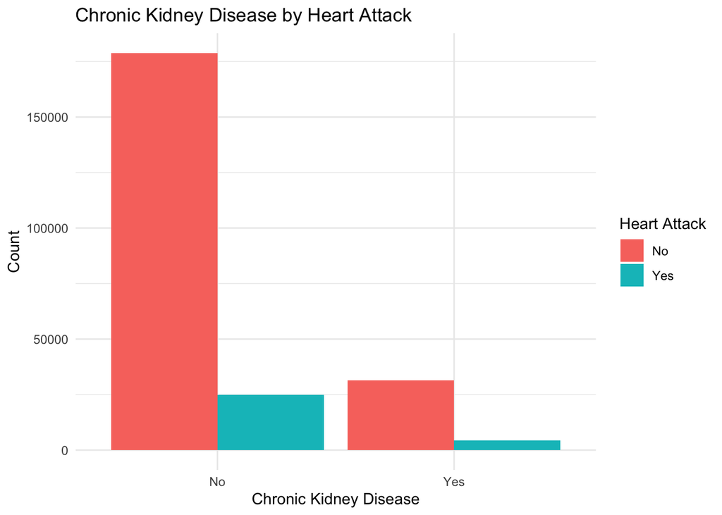

```r
ggplot(data, aes(x = Chronic_Kidney_Disease, fill = Heart_Attack)) +
  geom_bar(position = "dodge") +
  labs(
    title = "Chronic Kidney Disease by Heart Attack",
    x = "Chronic Kidney Disease",
    y = "Count",
    fill = "Heart Attack"
  ) +
  theme_minimal()
```

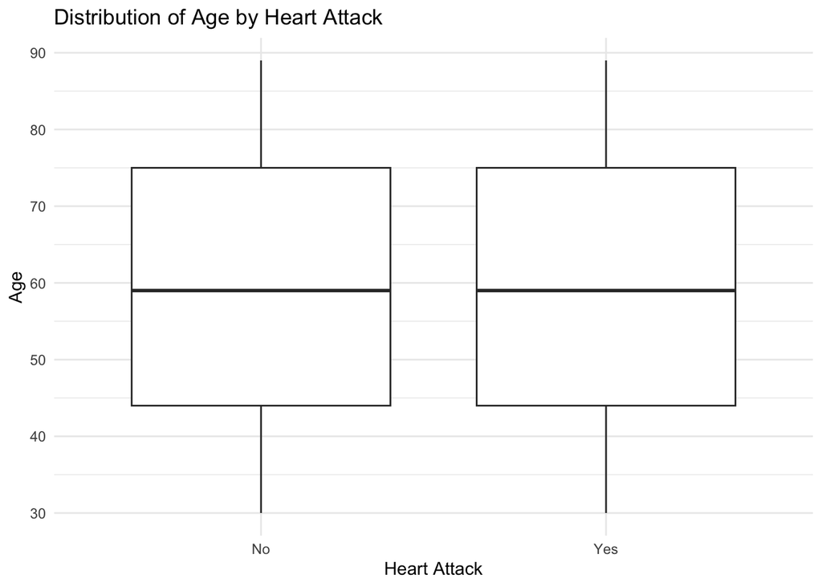

```r
ggplot(data, aes(x = Heart_Attack, y = Age)) +
  geom_boxplot() +
  labs(
    x = "Heart Attack",
    y = "Age",
    title = "Distribution of Age by Heart Attack"
  ) +
  theme_minimal()
```

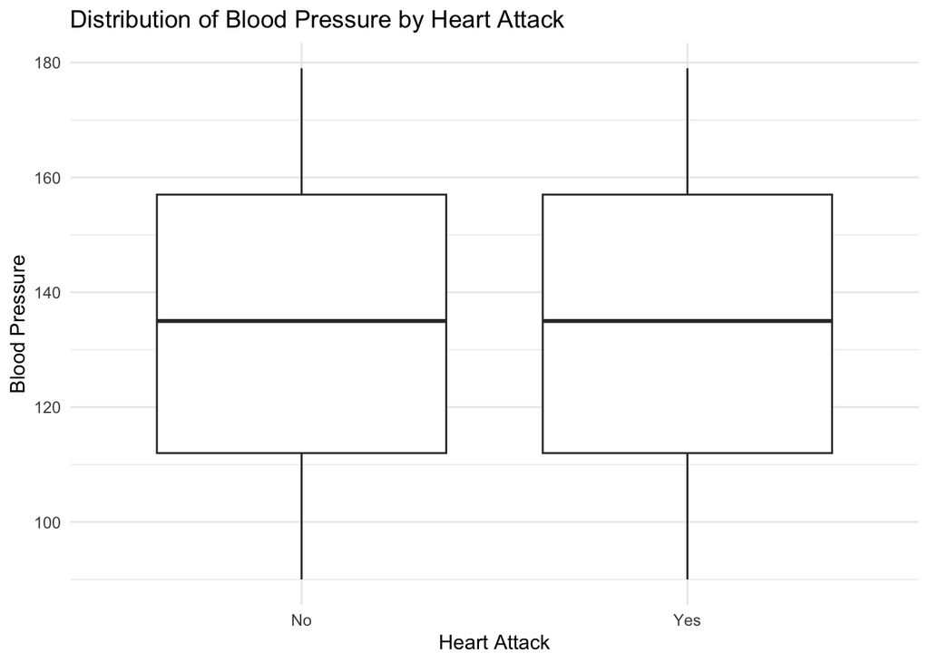

```r
ggplot(data, aes(x = Heart_Attack, y = Blood_Pressure)) +
  geom_boxplot() +
  labs(
    x = "Heart Attack",
    y = "Blood Pressure",
    title = "Distribution of Blood Pressure by Heart Attack"
  ) +
  theme_minimal()
```

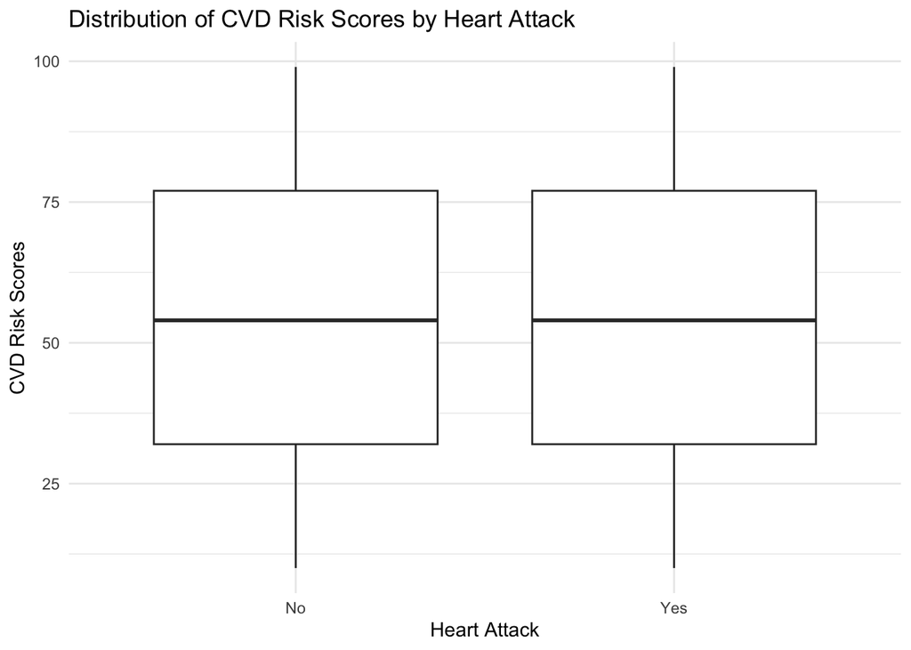

```r
ggplot(data, aes(x = Heart_Attack, y = CVD_Risk_Score)) +
  geom_boxplot() +
  labs(
    x = "Heart Attack",
    y = "CVD Risk Scores",
    title = "Distribution of CVD Risk Scores by Heart Attack"
  ) +
  theme_minimal()
```

# Machine Learning Models

## Logistic Regression

### Loading the packages

```r
library(tidyverse)
library(tidymodels)
library(sjPlot)
library(finalfit)
library(knitr)
library(gtsummary)
library(mlbench)
library(vip)
library(rsample)
library(tune)
library(recipes)
library(yardstick)
library(parsnip)
library(glmnet)
library(themis)
library(microbenchmark)
```

### Data Split

```r
set.seed(10)

data_split <- initial_split(data, prop = 0.70, strata = Heart_Attack)

train_data <- training(data_split)
table(train_data$Heart_Attack)
```

```
##
##     No    Yes
## 147136  20349
```

```r
test_data  <- testing(data_split)
table(test_data$Heart_Attack)
```

```
##
##    No   Yes
## 63059  8722
```

The data is split into training and testing datasets using 70-30 splitting rule.

### Creating 10-fold splits

```r
set.seed(10)

folds <- vfold_cv(train_data, v = 10, strata= Heart_Attack)
```

### Setting the reference of dependent variable

```r
train_data$Heart_Attack <- relevel(factor(train_data$Heart_Attack), ref = "No")
```

### Defining logistic regression model

```r
logistic_model <- logistic_reg() %>%
        set_engine("glm", control= list(maxit=200)) %>%
        set_mode("classification")
```

### Creating recipe

```r
rec <- recipe(Heart_Attack ~ ., data = train_data) %>%
  step_rm(Patient_ID, Province, Hypertension) %>%
  step_naomit(all_predictors(), skip = TRUE) %>%
  step_nzv(all_predictors()) %>%
  step_corr(all_numeric_predictors(), threshold = 0.9) %>%
  step_dummy(all_nominal_predictors()) %>%
  step_normalize(all_numeric_predictors())
```

### Creating a workflow

```r
wf <- workflow() %>%
  add_model(logistic_model) %>%
  add_recipe(rec)
```

### Running 10_fold cross validation

```r
results <- fit_resamples(
  wf,
  resamples = folds,
  metrics = metric_set(accuracy, roc_auc),
  control = control_resamples(save_pred = TRUE, verbose = FALSE)
)
```

### Collecting the metrics

```r
collect_metrics(results)
```

```
## # A tibble: 2 × 6
##   .metric  .estimator  mean     n    std_err .config
##   <chr>    <chr>      <dbl> <int>      <dbl> <chr>
## 1 accuracy binary     0.879    10 0.00000488 pre0_mod0_post0
## 2 roc_auc  binary     0.498    10 0.00137    pre0_mod0_post0
```

```r
preds <- collect_predictions(results)
```

The average accurcacy is 87.85% and average roc-auc is 49.77% respectively.

### Confusion Matrix (2 x 2 Table)

```r
conf_mat(preds, truth = Heart_Attack, estimate = .pred_class)
```

```
##           Truth
## Prediction     No    Yes
##        No  147136  20349
##        Yes      0      0
```

The model fails to predict anyone with heart attack, but accurately predict those without the heart attack.

### Model Performance metrics

```r
metrics <- metric_set(accuracy, sens, spec, precision, recall, f_meas)

all_metrics_lr <- metrics(preds,
               truth = Heart_Attack,
               estimate = .pred_class, event_level = "second")
kable(all_metrics_lr)
```

| .metric | .estimator | .estimate |
| --- | --- | --- |
| accuracy | binary | 0.8785026 |
| sens | binary | 0.0000000 |
| spec | binary | 1.0000000 |
| precision | binary |  |
| recall | binary | 0.0000000 |
| f_meas | binary |  |

### ROC Plot

```r
roc_auc(preds,
        truth = Heart_Attack,
        .pred_Yes)
```

```
## # A tibble: 1 × 3
##   .metric .estimator .estimate
##   <chr>   <chr>          <dbl>
## 1 roc_auc binary         0.502
```

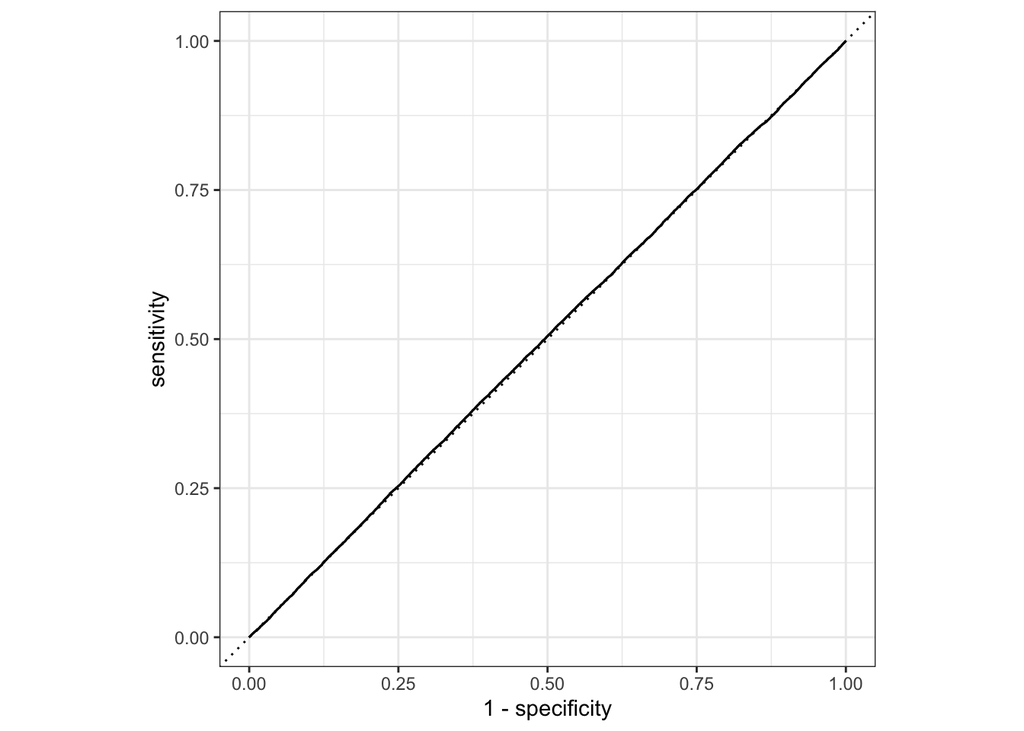

```r
roc_curve <- preds %>%
  roc_curve(truth = Heart_Attack, .pred_Yes) %>%
  autoplot()

plot(roc_curve)
```

### Coefficient Estimates

```r
final_model <- fit(wf, data = train_data)


fitted_model <- final_model %>% extract_fit_engine()
tidy(fitted_model)
```

```
## # A tibble: 39 × 5
##    term                      estimate std.error statistic p.value
##    <chr>                        <dbl>     <dbl>     <dbl>   <dbl>
##  1 (Intercept)              -1.98       0.00748 -264.      0
##  2 Age                      -0.00742    0.00748   -0.991   0.322
##  3 Blood_Pressure            0.00317    0.00748    0.424   0.672
##  4 CVD_Risk_Score           -0.00770    0.00748   -1.03    0.303
##  5 Gender_Male              -0.000138   0.00748   -0.0184  0.985
##  6 Smoking_Status_Smoker    -0.00607    0.00748   -0.811   0.417
##  7 Diabetes_Yes             -0.00439    0.00751   -0.584   0.559
##  8 Obesity_Yes               0.00559    0.00747    0.749   0.454
##  9 Cholesterol_Level_Low    -0.0179     0.00865   -2.07    0.0388
## 10 Cholesterol_Level_Normal -0.00852    0.00861   -0.989   0.322
## # ℹ 29 more rows
```

### Variables Importance

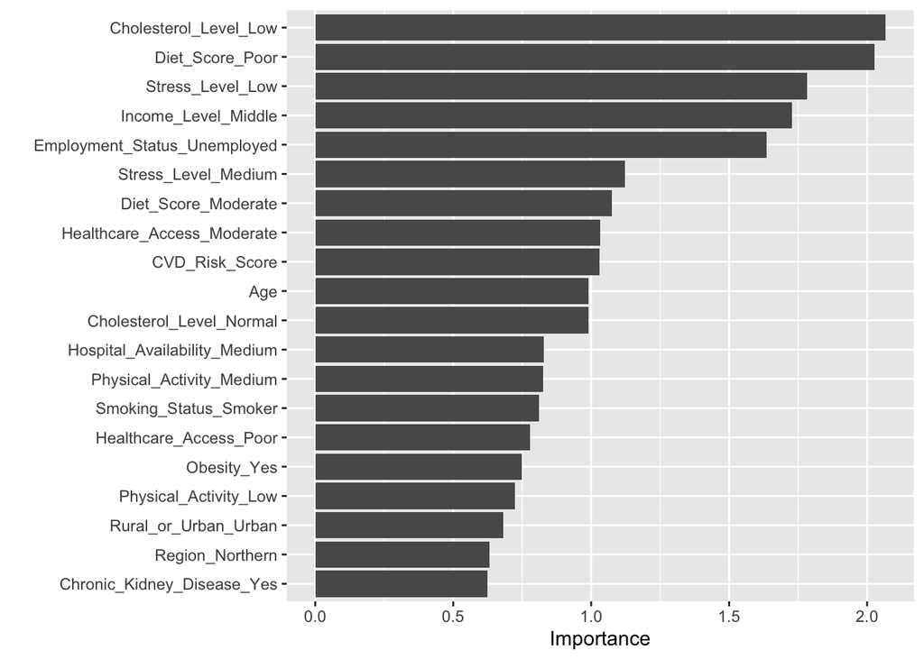

```r
final_model %>%
  extract_fit_parsnip() %>%
  vip(num_features = 20)
```

The top 5 variables that are found to be most important in logistic regression are Low cholesterol level, poor diet score, low stress level, middle income level and unemployed.

### Testing the final model on testing dataset

```r
test_preds <- predict(final_model, new_data = test_data, type = "class") %>%
  bind_cols(test_data)
```

### Confusion metrics for testing data

```r
conf_mat(test_preds,
         truth = Heart_Attack,
         estimate = .pred_class)
```

```
##           Truth
## Prediction    No   Yes
##        No  63059  8722
##        Yes     0     0
```

The final model fails to predict anyone with heart attack, but accurately predict those without the heart attack.

### calculating different metrics for testing data

```r
metrics <- metric_set(accuracy, sens, spec, precision, recall, f_meas)

metrics(test_preds,
        truth = Heart_Attack,
        estimate = .pred_class,
        event_level = "second")
```

```
## # A tibble: 6 × 3
##   .metric   .estimator .estimate
##   <chr>     <chr>          <dbl>
## 1 accuracy  binary         0.878
## 2 sens      binary         0
## 3 spec      binary         1
## 4 precision binary        NA
## 5 recall    binary         0
## 6 f_meas    binary        NA
```

## Logistic regression with up- sampling

###Creating the Recipe

```r
Heart_rec_oversamp <-
  recipe(Heart_Attack ~ ., data = train_data) %>%
  step_rm(Patient_ID, Province, Hypertension) %>%
  step_smotenc(Heart_Attack, over_ratio = 0.9) %>%
  step_dummy(all_nominal_predictors()) %>%
  step_normalize(all_numeric_predictors()) %>%
  step_corr(all_numeric_predictors(), threshold = 0.9) %>%
  step_nzv(all_predictors())
```

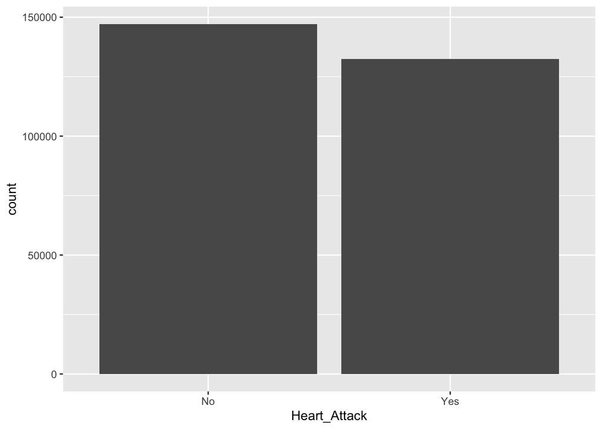

```r
recipe(~., train_data) %>%
  step_upsample(Heart_Attack, over_ratio = 0.9) %>%
  prep() %>%
  bake(new_data = NULL) %>%
  ggplot(aes(Heart_Attack)) +
  geom_bar()
```

### Define Logistic Regression

```r
logistic_m <- logistic_reg(
                mode = "classification",
                engine = "glm"
              )
```

### Creating Workflow

```r
HeartAttack_wflow_oversamp <-
  workflow() %>%
  add_model(logistic_m) %>%
  add_recipe(Heart_rec_oversamp)

HeartAttack_wflow_oversamp
```

```
## ══ Workflow ════════════════════════════════════════════════════════════════════
## Preprocessor: Recipe
## Model: logistic_reg()
##
## ── Preprocessor ────────────────────────────────────────────────────────────────
## 6 Recipe Steps
##
## • step_rm()
## • step_smotenc()
## • step_dummy()
## • step_normalize()
## • step_corr()
## • step_nzv()
##
## ── Model ───────────────────────────────────────────────────────────────────────
## Logistic Regression Model Specification (classification)
##
## Computational engine: glm
```

### ### Running 10-fold cross validation

```r
Heart_fit_oversamp <-
  fit_resamples(
    HeartAttack_wflow_oversamp,
    resamples = folds,
    metrics = metric_set(accuracy, roc_auc),
    control = control_resamples(save_pred = TRUE, verbose = FALSE)
  )
```

### Collecting the results

```r
collect_metrics(Heart_fit_oversamp)
```

```
## # A tibble: 2 × 6
##   .metric  .estimator  mean     n std_err .config
##   <chr>    <chr>      <dbl> <int>   <dbl> <chr>
## 1 accuracy binary     0.558    10 0.00135 pre0_mod0_post0
## 2 roc_auc  binary     0.502    10 0.00188 pre0_mod0_post0
```

### Model performance metrics

```r
preds2 <- collect_predictions(Heart_fit_oversamp)

metrics <- metric_set(accuracy, sens, spec, precision, recall, f_meas)
Heart_fit_oversamp_all_metrics <- metrics(preds2,
                                          truth = Heart_Attack,
                                          estimate = .pred_class,
                                          event_level = "second")
kable(Heart_fit_oversamp_all_metrics)
```

| .metric | .estimator | .estimate |
| --- | --- | --- |
| accuracy | binary | 0.5579783 |
| sens | binary | 0.4293086 |
| spec | binary | 0.5757734 |
| precision | binary | 0.1227742 |
| recall | binary | 0.4293086 |
| f_meas | binary | 0.1909425 |

### ROC Curve

```r
roc_auc(preds2, truth = Heart_Attack, .pred_Yes)
```

```
## # A tibble: 1 × 3
##   .metric .estimator .estimate
##   <chr>   <chr>          <dbl>
## 1 roc_auc binary         0.498
```

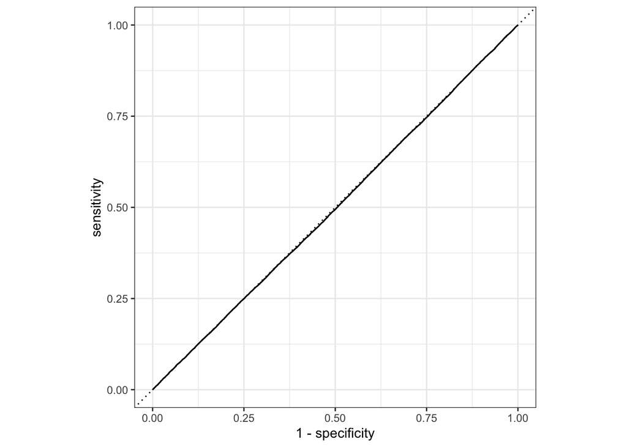

```r
preds2 %>%
  roc_curve(truth = Heart_Attack, .pred_Yes) %>%
  autoplot()
```

### Fitting the final model on entire training data

```r
final_model2 <- fit(HeartAttack_wflow_oversamp, data = train_data)


final_model2 %>%
  extract_fit_parsnip() %>%
  tidy() %>%
  arrange(desc(abs(estimate)))
```

```
## # A tibble: 39 × 5
##    term                          estimate std.error statistic   p.value
##    <chr>                            <dbl>     <dbl>     <dbl>     <dbl>
##  1 Previous_Heart_Attack_Yes      -0.211    0.00415    -50.7  0
##  2 Diabetes_Yes                   -0.195    0.00407    -47.8  0
##  3 Chronic_Kidney_Disease_Yes     -0.176    0.00397    -44.2  0
##  4 Air_Pollution_Exposure_Medium   0.133    0.00525     25.4  6.22e-142
##  5 (Intercept)                    -0.115    0.00386    -29.7  9.79e-194
##  6 Family_History_CVD_Yes         -0.110    0.00388    -28.3  7.15e-176
##  7 Obesity_Yes                    -0.0752   0.00387    -19.4  3.02e- 84
##  8 Alcohol_Consumption_Yes        -0.0746   0.00387    -19.3  5.38e- 83
##  9 Air_Pollution_Exposure_Low      0.0687   0.00524     13.1  3.07e- 39
## 10 Rural_or_Urban_Urban           -0.0340   0.00386     -8.82 1.18e- 18
## # ℹ 29 more rows
```

### Variables Importance

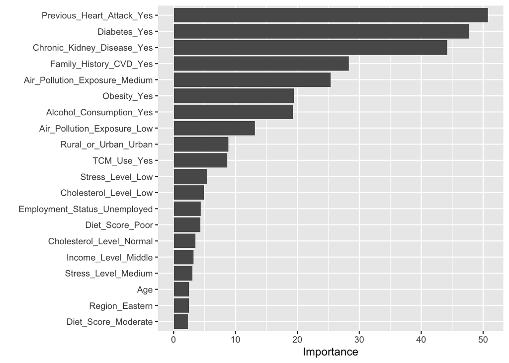

```r
final_model2 %>%
  extract_fit_parsnip() %>%
  vip(num_features = 20)
```

### Testing the final model on testing dataset

```r
test_preds2 <- predict(final_model2, new_data = test_data, type = "class") %>%
  bind_cols(test_data)
```

### Confusion metrics for testing data

```r
conf_mat(test_preds2,
         truth = Heart_Attack,
         estimate = .pred_class)
```

```
##           Truth
## Prediction    No   Yes
##        No  36145  5057
##        Yes 26914  3665
```

### calculating different metrics for testing data

```r
metrics <- metric_set(accuracy, sens, spec, precision, recall, f_meas)

metrics(test_preds2,
        truth = Heart_Attack,
        estimate = .pred_class,
        event_level = "second")
```

```
## # A tibble: 6 × 3
##   .metric   .estimator .estimate
##   <chr>     <chr>          <dbl>
## 1 accuracy  binary         0.555
## 2 sens      binary         0.420
## 3 spec      binary         0.573
## 4 precision binary         0.120
## 5 recall    binary         0.420
## 6 f_meas    binary         0.187
```

## Random Forests

### Loading the Libraries

```r
library(tidyverse)
library(tidymodels)
library(sjPlot)
library(C50)
library(ranger)
library(finalfit)
library(knitr)
library(gtsummary)
library(mlbench)
library(vip)
library(rsample)
library(rpart.plot)
library(tune)
library(recipes)
library(yardstick)
library(parsnip)
library(glmnet)
library(themis)
library(microbenchmark)
```

### Setting the cores for fast computation

```r
### Set the number of cores on your computer
cores <- parallel::detectCores()
cores
```

```
## [1] 10
```

### Defining Random forest

```r
rf_model <- rand_forest(mtry = tune(), min_n = tune(), trees = 100) %>%
              set_engine("ranger", num.threads = cores) %>%
              set_mode("classification")
```

### Creating the recipe

```r
heartattack_recipe <-
  recipe(Heart_Attack ~ ., data = train_data) %>%
  step_rm(Patient_ID, Province, Hypertension) %>%
   step_dummy(all_nominal_predictors()) %>%
   step_normalize(all_numeric_predictors()) %>%
  step_corr(all_numeric_predictors(), threshold = 0.9) %>%
  step_nzv(all_predictors())
```

### Creating workflow

```r
heartattack_workflow <-
        workflow() %>%
        add_model(rf_model) %>%
        add_recipe(heartattack_recipe)

heartattack_workflow
```

```
## ══ Workflow ════════════════════════════════════════════════════════════════════
## Preprocessor: Recipe
## Model: rand_forest()
##
## ── Preprocessor ────────────────────────────────────────────────────────────────
## 5 Recipe Steps
##
## • step_rm()
## • step_dummy()
## • step_normalize()
## • step_corr()
## • step_nzv()
##
## ── Model ───────────────────────────────────────────────────────────────────────
## Random Forest Model Specification (classification)
##
## Main Arguments:
##   mtry = tune()
##   trees = 100
##   min_n = tune()
##
## Engine-Specific Arguments:
##   num.threads = cores
##
## Computational engine: ranger
```

### creating 10-folds and creating grid to find optimal hyperparameters

```r
set.seed(10)

folds <- vfold_cv(train_data, v = 10)

rf_grid <- grid_regular(
              mtry(range = c(5, 25)),
              min_n(range = c(5, 50)),
              levels = 5
            )

rf_grid
```

```
## # A tibble: 25 × 2
##     mtry min_n
##    <int> <int>
##  1     5     5
##  2    10     5
##  3    15     5
##  4    20     5
##  5    25     5
##  6     5    16
##  7    10    16
##  8    15    16
##  9    20    16
## 10    25    16
## # ℹ 15 more rows
```

### Running the random forest model

```r
heartattack_fit <- tune_grid(
                heartattack_workflow,
                resamples = folds,
                grid = rf_grid,
                control = control_resamples(save_pred = TRUE,
                                                  verbose = FALSE))

heartattack_fit
```

```
## # Tuning results
## # 10-fold cross-validation
## # A tibble: 10 × 5
##    splits                 id     .metrics          .notes           .predictions
##    <list>                 <chr>  <list>            <list>           <list>
##  1 <split [150736/16749]> Fold01 <tibble [75 × 6]> <tibble [0 × 4]> <tibble>
##  2 <split [150736/16749]> Fold02 <tibble [75 × 6]> <tibble [0 × 4]> <tibble>
##  3 <split [150736/16749]> Fold03 <tibble [75 × 6]> <tibble [0 × 4]> <tibble>
##  4 <split [150736/16749]> Fold04 <tibble [75 × 6]> <tibble [0 × 4]> <tibble>
##  5 <split [150736/16749]> Fold05 <tibble [75 × 6]> <tibble [0 × 4]> <tibble>
##  6 <split [150737/16748]> Fold06 <tibble [75 × 6]> <tibble [0 × 4]> <tibble>
##  7 <split [150737/16748]> Fold07 <tibble [75 × 6]> <tibble [0 × 4]> <tibble>
##  8 <split [150737/16748]> Fold08 <tibble [75 × 6]> <tibble [0 × 4]> <tibble>
##  9 <split [150737/16748]> Fold09 <tibble [75 × 6]> <tibble [0 × 4]> <tibble>
## 10 <split [150737/16748]> Fold10 <tibble [75 × 6]> <tibble [0 × 4]> <tibble>
```

### Graph showing accuracy as a function of min_n and mtry

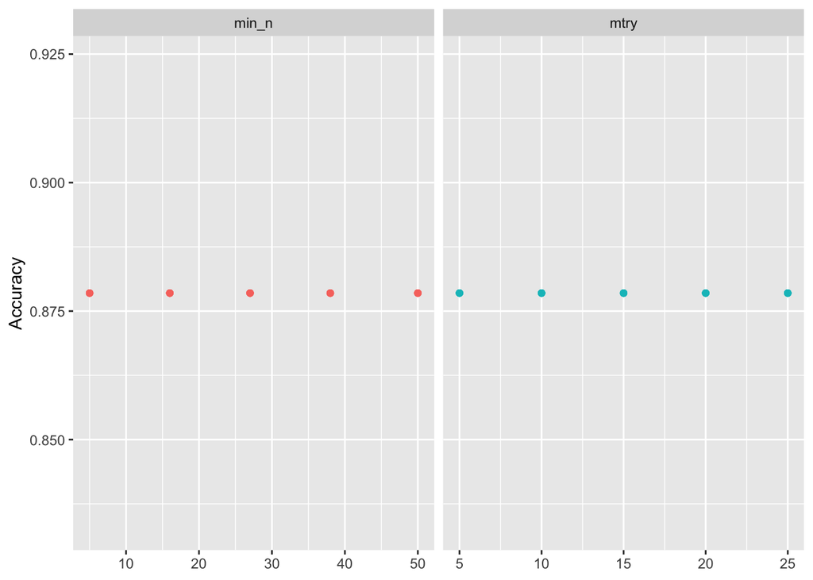

```r
heartattack_fit %>%
  collect_metrics() %>%
  filter(.metric == "accuracy") %>%
  select(mean, min_n, mtry) %>%
  pivot_longer(min_n:mtry,
    values_to = "value",
    names_to = "parameter"
  ) %>%
  ggplot(aes(value, mean, color = parameter)) +
  geom_point(show.legend = FALSE) +
  facet_wrap(~parameter, scales = "free_x") +
  labs(x = NULL, y = "Accuracy")
```

### Collect the results

```r
rf_best <-
  heartattack_fit %>%
  select_best(metric = "accuracy")

rf_best
```

```
## # A tibble: 1 × 3
##    mtry min_n .config
##   <int> <int> <chr>
## 1     5     5 pre0_mod01_post0
```

```r
rf_auc_fit <-
  heartattack_fit %>%
  collect_predictions(parameters = rf_best)
```

The optimal tuning parameters are mtry =5 (each split, only 5 random predictors are considered) and min_n = 5 (each node must have atleast 5 observations to split further).

### Confusion matrix

```r
conf_mat(rf_auc_fit, truth = Heart_Attack,
         estimate = .pred_class)
```

```
##           Truth
## Prediction     No    Yes
##        No  147136  20349
##        Yes      0      0
```

The model fails to predict anyone with the heart attack, but perform well to predict those without the heart attack.

### Model Performance metrics

```r
metrics2 <- metric_set(accuracy, sens, spec, precision, recall, f_meas)

all_metrics_lr2 <- metrics2(rf_auc_fit,
               truth = Heart_Attack,
               estimate = .pred_class, event_level = "second")
kable(all_metrics_lr2)
```

| .metric | .estimator | .estimate |
| --- | --- | --- |
| accuracy | binary | 0.8785026 |
| sens | binary | 0.0000000 |
| spec | binary | 1.0000000 |
| precision | binary |  |
| recall | binary | 0.0000000 |
| f_meas | binary |  |

### ROC-AUC for random forest

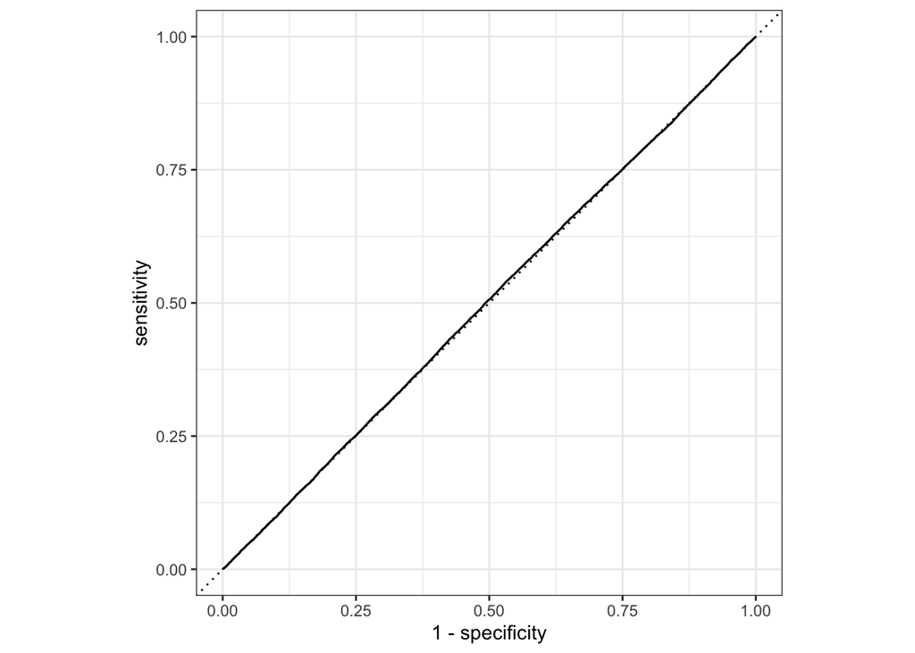

```r
auc_result <- roc_auc(
  rf_auc_fit,
  truth = Heart_Attack,
  .pred_Yes,
  event_level = "second"
)
rf_auc_fit %>%
  roc_curve(truth = Heart_Attack, .pred_Yes) %>%
  autoplot()
```

### Final model

```r
final_modelRF <- finalize_model(
                  rf_model,
                  rf_best
                )

final_modelRF
```

```
## Random Forest Model Specification (classification)
##
## Main Arguments:
##   mtry = 5
##   trees = 100
##   min_n = 5
##
## Engine-Specific Arguments:
##   num.threads = cores
##
## Computational engine: ranger
```

### Variable Importance

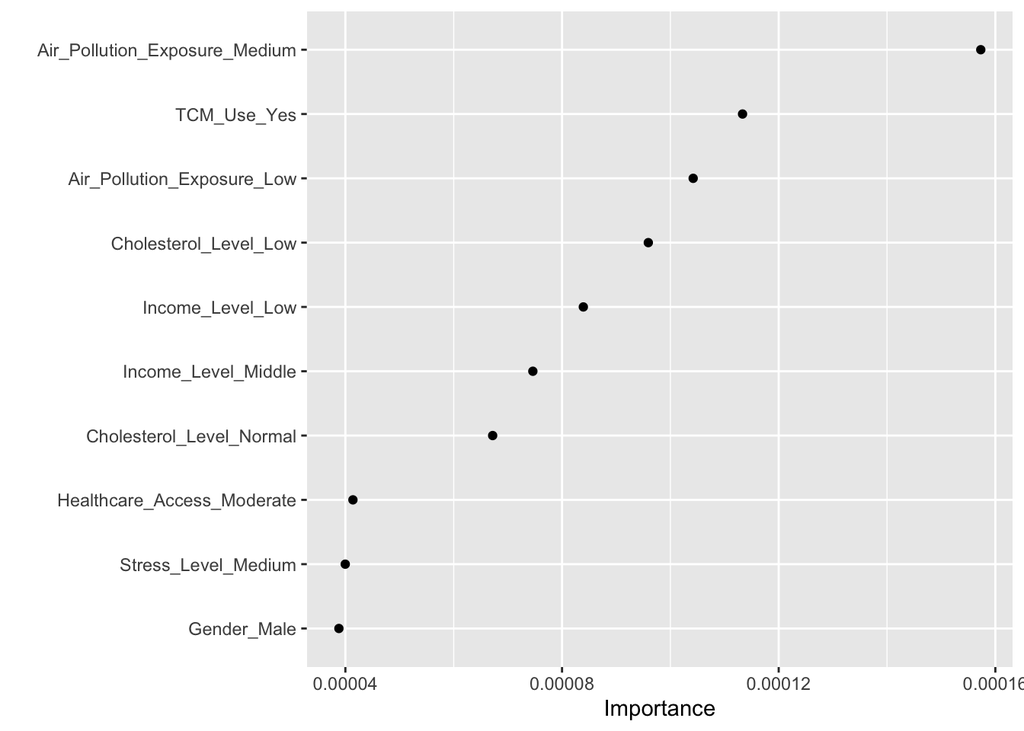

```r
tree_prep <- prep(heartattack_recipe)

final_modelRF %>%
  set_engine("ranger", importance = "permutation") %>%
  fit(Heart_Attack ~ .,
    data = juice(tree_prep)) %>%
  vip(geom = "point")
```

### Fitting the final model using the optimal hyperparameters and testing the peformance on testing data

```r
final_rf_workflow <- workflow() %>%
                      add_recipe(heartattack_recipe) %>%
                      add_model(final_modelRF)

final_resultsRF <- final_rf_workflow %>%
                    last_fit(data_split)

final_resultsRF %>%
  collect_metrics()
```

```
## # A tibble: 3 × 4
##   .metric     .estimator .estimate .config
##   <chr>       <chr>          <dbl> <chr>
## 1 accuracy    binary         0.878 pre0_mod0_post0
## 2 roc_auc     binary         0.507 pre0_mod0_post0
## 3 brier_class binary         0.108 pre0_mod0_post0
```

### Collecting the predictions

```r
rf_predictions <- final_resultsRF %>%
  collect_predictions()
```

### Confusion matrix based on testing data

```r
rf_predictions %>%
  conf_mat(truth = Heart_Attack, estimate = .pred_class)
```

```
##           Truth
## Prediction    No   Yes
##        No  63059  8722
##        Yes     0     0
```

The model fails to predict anyone with the heart attack, but perform well to predict those without the heart attack.

### Metrics for Random forest based on testing data

```r
metricsRF <- metric_set(accuracy, sens, spec, precision, recall, f_meas)

all_metrics_RF <- metricsRF(rf_predictions,
               truth = Heart_Attack,
               estimate = .pred_class, event_level = "second")
kable(all_metrics_RF)
```

| .metric | .estimator | .estimate |
| --- | --- | --- |
| accuracy | binary | 0.8784915 |
| sens | binary | 0.0000000 |
| spec | binary | 1.0000000 |
| precision | binary |  |
| recall | binary | 0.0000000 |
| f_meas | binary |  |

### ROC-AUC for random forest

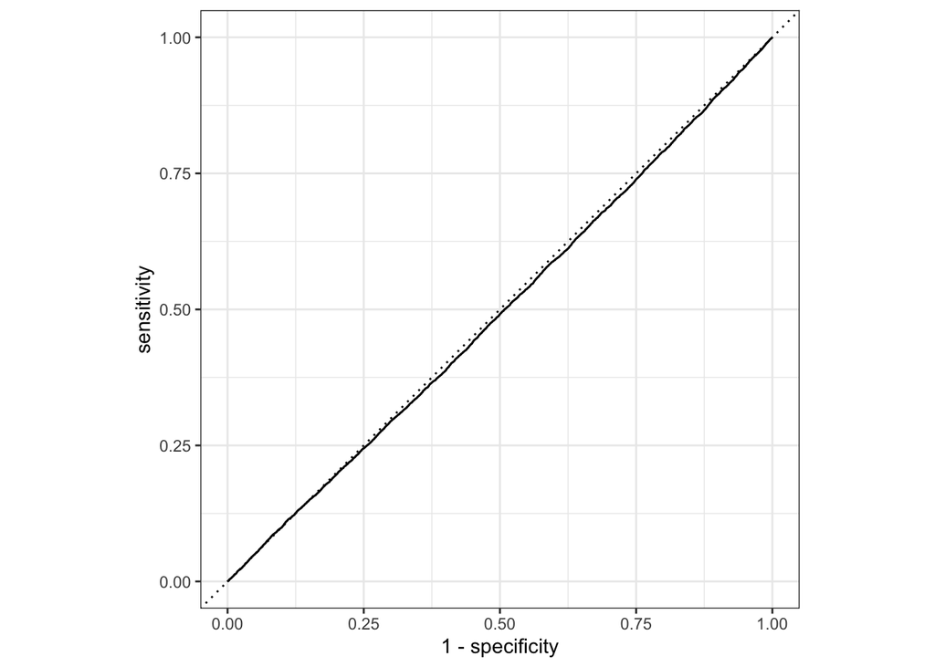

```r
auc_result2 <- roc_auc(
  rf_predictions,
  truth = Heart_Attack,
  .pred_Yes,
  event_level = "second"
)
rf_predictions %>%
  roc_curve(truth = Heart_Attack, .pred_Yes) %>%
  autoplot()
```

## Random forest for up sampling

### Setting the cores for fast computation

```r
cores <- parallel::detectCores()
cores
```

```
## [1] 10
```

### Creating the Recipe

```r
Heart_rec_oversamp_rf2 <-
  recipe(Heart_Attack ~ ., data = train_data) %>%
  step_rm(Patient_ID, Province, Hypertension) %>%
  step_dummy(all_nominal_predictors()) %>%
  step_normalize(all_numeric_predictors()) %>%
  step_nzv(all_predictors()) %>%
  step_corr(all_numeric_predictors(), threshold = 0.9) %>%
  step_smotenc(Heart_Attack, over_ratio = 0.9)
```

### Defining the Random forest

```r
rf_model <- rand_forest(mtry = tune(), min_n = tune(), trees = 100) %>%
              set_engine("ranger", num.threads = cores) %>%
              set_mode("classification")
```

### Creating the workflow

```r
HeartAttack_wflow_oversamp_rf <-
  workflow() %>%
  add_model(rf_model) %>%
  add_recipe(Heart_rec_oversamp_rf2)

HeartAttack_wflow_oversamp_rf
```

```
## ══ Workflow ════════════════════════════════════════════════════════════════════
## Preprocessor: Recipe
## Model: rand_forest()
##
## ── Preprocessor ────────────────────────────────────────────────────────────────
## 6 Recipe Steps
##
## • step_rm()
## • step_dummy()
## • step_normalize()
## • step_nzv()
## • step_corr()
## • step_smotenc()
##
## ── Model ───────────────────────────────────────────────────────────────────────
## Random Forest Model Specification (classification)
##
## Main Arguments:
##   mtry = tune()
##   trees = 100
##   min_n = tune()
##
## Engine-Specific Arguments:
##   num.threads = cores
##
## Computational engine: ranger
```

### Tuning the parameters

```r
rf_grid <- grid_regular(
  mtry(range = c(5, 25)),
  min_n(range = c(5, 50)),
  levels = 5
)
```

### Running the model

```r
rfoversamp_results <- tune_grid(
  HeartAttack_wflow_oversamp_rf,
  resamples = folds,
  grid = rf_grid,
  control = control_resamples(save_pred = TRUE,
                                                  verbose = FALSE))
```

### Graph showing accuracy as a function of min_n and mtry

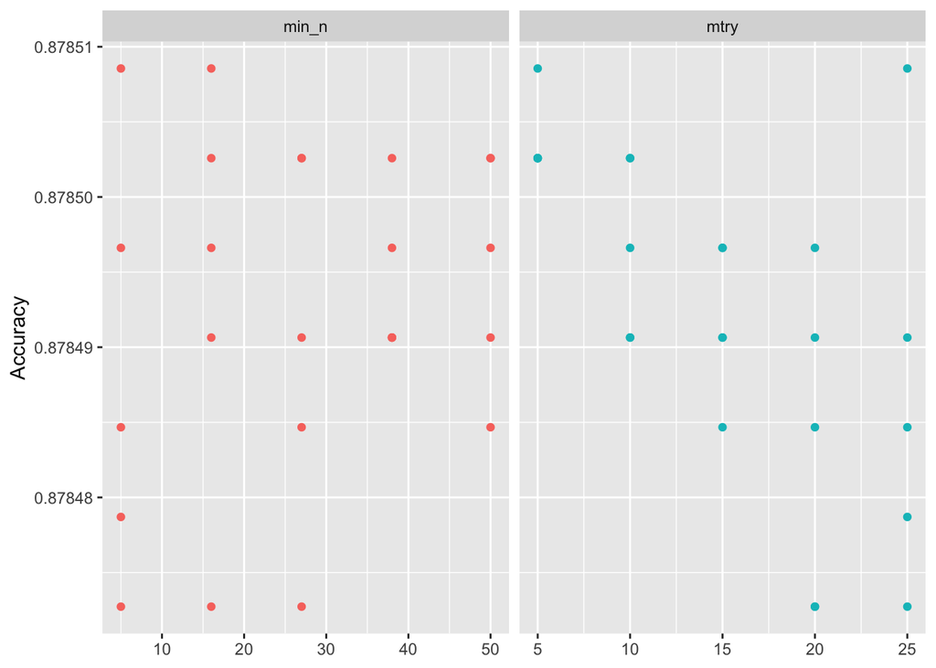

```r
rfoversamp_results %>%
  collect_metrics() %>%
  filter(.metric == "accuracy") %>%
  select(mean, min_n, mtry) %>%
  pivot_longer(min_n:mtry,
    values_to = "value",
    names_to = "parameter"
  ) %>%
  ggplot(aes(value, mean, color = parameter)) +
  geom_point(show.legend = FALSE) +
  facet_wrap(~parameter, scales = "free_x") +
  labs(x = NULL, y = "Accuracy")
```

### Collecting the results

```r
rf_best2 <-
  rfoversamp_results %>%
  select_best(metric = "accuracy")

rf_best2
```

```
## # A tibble: 1 × 3
##    mtry min_n .config
##   <int> <int> <chr>
## 1     5     5 pre0_mod01_post0
```

```r
rf_auc_fit2 <-
  rfoversamp_results %>%
  collect_predictions(parameters = rf_best2)
```

The optimal tuning parameters are mtry =5 (each split, only 5 random predictors are considered) and min_n = 5 (each node must have atleast 5 observations to split further).

### Confusion matrix

```r
conf_mat(rf_auc_fit2, truth = Heart_Attack,
         estimate = .pred_class)
```

```
##           Truth
## Prediction     No    Yes
##        No  147136  20348
##        Yes      0      1
```

### Model Performance metrics

```r
metricsRFU <- metric_set(accuracy, sens, spec, precision, recall, f_meas)

all_metrics_RFU <- metricsRFU(rf_auc_fit2,
               truth = Heart_Attack,
               estimate = .pred_class, event_level = "second")

kable(all_metrics_RFU)
```

| .metric | .estimator | .estimate |
| --- | --- | --- |
| accuracy | binary | 0.8785085 |
| sens | binary | 0.0000491 |
| spec | binary | 1.0000000 |
| precision | binary | 1.0000000 |
| recall | binary | 0.0000491 |
| f_meas | binary | 0.0000983 |